# Project: Investigate "Database TMDb movie data"

- Introduction
- Data Wrangling
- Exploratory Data Analysis
- Conclusions

## Introduction

### Dataset Description

#### This data set contains information about 10,000 movies collected from The Movie Database (TMDb), including user ratings and revenue.

- Certain columns, like ‘cast’ and ‘genres’, contain multiple values separated by pipe (|) characters.
- There are some odd characters in the ‘cast’ column.
- The final two columns ending with “_adj” show the budget and revenue of the associated movie in terms of 2010 dollars, accounting for inflation over time.

### Question(s) for Analysis

- Which year has the highest release of movies?
- What is the most common average vote?
- What is correlation between "revenue, budget and movie popularity, ..."?
- Who is the top 10 Directors?
- Which Genre Has The Highest Release Of Movies?
- Who is the actor that has The Highest Release Of Movies?

```python
#loading necessary libraries

import pandas as pd
import numpy as np
import matplotlib.pyplot as plt
import seaborn as sns
% matplotlib inline
```

## Data Wrangling

### Uploading data and show the first 5 rows :

```python
# Load your data and show a sample of it

df = pd.read_csv('tmdb-movies.csv')
df.head()
```

|  | id | imdb_id | popularity | budget | revenue | original_title | cast | homepage | director | tagline | ... | overview | runtime | genres | production_companies | release_date | vote_count | vote_average | release_year | budget_adj | revenue_adj |
| --- | --- | --- | --- | --- | --- | --- | --- | --- | --- | --- | --- | --- | --- | --- | --- | --- | --- | --- | --- | --- | --- |
| 0 | 135397 | tt0369610 | 32.985763 | 150000000 | 1513528810 | Jurassic World | Chris Pratt\|Bryce Dallas Howard\|Irrfan Khan\|Vi... | http://www.jurassicworld.com/ | Colin Trevorrow | The park is open. | ... | Twenty-two years after the events of Jurassic ... | 124 | Action\|Adventure\|Science Fiction\|Thriller | Universal Studios\|Amblin Entertainment\|Legenda... | 6/9/15 | 5562 | 6.5 | 2015 | 1.379999e+08 | 1.392446e+09 |
| 1 | 76341 | tt1392190 | 28.419936 | 150000000 | 378436354 | Mad Max: Fury Road | Tom Hardy\|Charlize Theron\|Hugh Keays-Byrne\|Nic... | http://www.madmaxmovie.com/ | George Miller | What a Lovely Day. | ... | An apocalyptic story set in the furthest reach... | 120 | Action\|Adventure\|Science Fiction\|Thriller | Village Roadshow Pictures\|Kennedy Miller Produ... | 5/13/15 | 6185 | 7.1 | 2015 | 1.379999e+08 | 3.481613e+08 |
| 2 | 262500 | tt2908446 | 13.112507 | 110000000 | 295238201 | Insurgent | Shailene Woodley\|Theo James\|Kate Winslet\|Ansel... | http://www.thedivergentseries.movie/#insurgent | Robert Schwentke | One Choice Can Destroy You | ... | Beatrice Prior must confront her inner demons ... | 119 | Adventure\|Science Fiction\|Thriller | Summit Entertainment\|Mandeville Films\|Red Wago... | 3/18/15 | 2480 | 6.3 | 2015 | 1.012000e+08 | 2.716190e+08 |
| 3 | 140607 | tt2488496 | 11.173104 | 200000000 | 2068178225 | Star Wars: The Force Awakens | Harrison Ford\|Mark Hamill\|Carrie Fisher\|Adam D... | http://www.starwars.com/films/star-wars-episod... | J.J. Abrams | Every generation has a story. | ... | Thirty years after defeating the Galactic Empi... | 136 | Action\|Adventure\|Science Fiction\|Fantasy | Lucasfilm\|Truenorth Productions\|Bad Robot | 12/15/15 | 5292 | 7.5 | 2015 | 1.839999e+08 | 1.902723e+09 |
| 4 | 168259 | tt2820852 | 9.335014 | 190000000 | 1506249360 | Furious 7 | Vin Diesel\|Paul Walker\|Jason Statham\|Michelle ... | http://www.furious7.com/ | James Wan | Vengeance Hits Home | ... | Deckard Shaw seeks revenge against Dominic Tor... | 137 | Action\|Crime\|Thriller | Universal Pictures\|Original Film\|Media Rights ... | 4/1/15 | 2947 | 7.3 | 2015 | 1.747999e+08 | 1.385749e+09 |

5 rows × 21 columns

### Getting info about Dataset :

```python
#show more details about data
df.info()
```

```
<class 'pandas.core.frame.DataFrame'>
RangeIndex: 10866 entries, 0 to 10865
Data columns (total 21 columns):
id                      10866 non-null int64
imdb_id                 10856 non-null object
popularity              10866 non-null float64
budget                  10866 non-null int64
revenue                 10866 non-null int64
original_title          10866 non-null object
cast                    10790 non-null object
homepage                2936 non-null object
director                10822 non-null object
tagline                 8042 non-null object
keywords                9373 non-null object
overview                10862 non-null object
runtime                 10866 non-null int64
genres                  10843 non-null object
production_companies    9836 non-null object
release_date            10866 non-null object
vote_count              10866 non-null int64
vote_average            10866 non-null float64
release_year            10866 non-null int64
budget_adj              10866 non-null float64
revenue_adj             10866 non-null float64
dtypes: float64(4), int64(6), object(11)
memory usage: 1.7+ MB
```

```python
#show numbers of rows and columns
df.shape
```

```
(10866, 21)
```

## Data Cleaning

### Checking Duplicated Rows:

```python
#checking the number of duplicates
df.duplicated().sum()
```

```
1
```

```python
# remove duplicates and check dulpicates again to verify
df.drop_duplicates(inplace= True)
df.duplicated().sum()
```

```
0
```

### Checking NAN values:

```python
# check the columns that have NA values
df.isnull().sum()
```

```
id                         0
imdb_id                   10
popularity                 0
budget                     0
revenue                    0
original_title             0
cast                      76
homepage                7929
director                  44
tagline                 2824
keywords                1493
overview                   4
runtime                    0
genres                    23
production_companies    1030
release_date               0
vote_count                 0
vote_average               0
release_year               0
budget_adj                 0
revenue_adj                0
dtype: int64
```

#### !!! I have found alot of NAN values in the dataset specially in some columns that will be unneeded in my analysis so I will delete these columns !!!

### Removing columns:

```python
# remove the columns that will not effect my analysis and already have NAN values
df.drop(['imdb_id','homepage','tagline','keywords','overview'], axis = 1 ,inplace=True)
#check that deleting done successfully
df.head()
```

|  | id | popularity | budget | revenue | original_title | cast | director | runtime | genres | production_companies | release_date | vote_count | vote_average | release_year | budget_adj | revenue_adj |
| --- | --- | --- | --- | --- | --- | --- | --- | --- | --- | --- | --- | --- | --- | --- | --- | --- |
| 0 | 135397 | 32.985763 | 150000000 | 1513528810 | Jurassic World | Chris Pratt\|Bryce Dallas Howard\|Irrfan Khan\|Vi... | Colin Trevorrow | 124 | Action\|Adventure\|Science Fiction\|Thriller | Universal Studios\|Amblin Entertainment\|Legenda... | 6/9/15 | 5562 | 6.5 | 2015 | 1.379999e+08 | 1.392446e+09 |
| 1 | 76341 | 28.419936 | 150000000 | 378436354 | Mad Max: Fury Road | Tom Hardy\|Charlize Theron\|Hugh Keays-Byrne\|Nic... | George Miller | 120 | Action\|Adventure\|Science Fiction\|Thriller | Village Roadshow Pictures\|Kennedy Miller Produ... | 5/13/15 | 6185 | 7.1 | 2015 | 1.379999e+08 | 3.481613e+08 |
| 2 | 262500 | 13.112507 | 110000000 | 295238201 | Insurgent | Shailene Woodley\|Theo James\|Kate Winslet\|Ansel... | Robert Schwentke | 119 | Adventure\|Science Fiction\|Thriller | Summit Entertainment\|Mandeville Films\|Red Wago... | 3/18/15 | 2480 | 6.3 | 2015 | 1.012000e+08 | 2.716190e+08 |
| 3 | 140607 | 11.173104 | 200000000 | 2068178225 | Star Wars: The Force Awakens | Harrison Ford\|Mark Hamill\|Carrie Fisher\|Adam D... | J.J. Abrams | 136 | Action\|Adventure\|Science Fiction\|Fantasy | Lucasfilm\|Truenorth Productions\|Bad Robot | 12/15/15 | 5292 | 7.5 | 2015 | 1.839999e+08 | 1.902723e+09 |
| 4 | 168259 | 9.335014 | 190000000 | 1506249360 | Furious 7 | Vin Diesel\|Paul Walker\|Jason Statham\|Michelle ... | James Wan | 137 | Action\|Crime\|Thriller | Universal Pictures\|Original Film\|Media Rights ... | 4/1/15 | 2947 | 7.3 | 2015 | 1.747999e+08 | 1.385749e+09 |

```python
# check new dimensions of dataset after deleting columns
df.shape
```

```
(10865, 16)
```

### Checking NAN values Again :

```python
# now after deleting unrequired columns I have to check nan-values again and take the appropiate action
df.isnull().sum()
```

```
id                         0
popularity                 0
budget                     0
revenue                    0
original_title             0
cast                      76
director                  44
runtime                    0
genres                    23
production_companies    1030
release_date               0
vote_count                 0
vote_average               0
release_year               0
budget_adj                 0
revenue_adj                0
dtype: int64
```

#### *** Now it's ok to dropping these NAN valuses

```python
# I decieded to drop the NAN values from dataset as number of records is enough to complete analysis without any bias
df.dropna(inplace= True)
# Ensure that dropping na done successfully
df.isnull().sum().any()
```

```
False
```

## Exploratory Data Analysis

### Descriptive Statistics:

#### Here I will check our dataset's descriptive statistics such as "average, minimum, maximum, standard diviation,.... etc " as shown below :

```python
df.describe()
```

|  | id | popularity | budget | revenue | runtime | vote_count | vote_average | release_year | budget_adj | revenue_adj |
| --- | --- | --- | --- | --- | --- | --- | --- | --- | --- | --- |
| count | 9772.000000 | 9772.000000 | 9.772000e+03 | 9.772000e+03 | 9772.000000 | 9772.000000 | 9772.000000 | 9772.000000 | 9.772000e+03 | 9.772000e+03 |
| mean | 63189.640810 | 0.694721 | 1.617967e+07 | 4.423121e+07 | 102.926627 | 239.312014 | 5.963528 | 2000.878428 | 1.941599e+07 | 5.705309e+07 |
| std | 90718.059987 | 1.036931 | 3.221074e+07 | 1.225889e+08 | 27.877432 | 603.011504 | 0.913174 | 13.036794 | 3.566634e+07 | 1.514499e+08 |
| min | 5.000000 | 0.000188 | 0.000000e+00 | 0.000000e+00 | 0.000000 | 10.000000 | 1.500000 | 1960.000000 | 0.000000e+00 | 0.000000e+00 |
| 25% | 10221.500000 | 0.232710 | 0.000000e+00 | 0.000000e+00 | 90.000000 | 18.000000 | 5.400000 | 1994.000000 | 0.000000e+00 | 0.000000e+00 |
| 50% | 18677.500000 | 0.419762 | 2.000000e+05 | 0.000000e+00 | 100.000000 | 46.000000 | 6.000000 | 2005.000000 | 3.061342e+05 | 0.000000e+00 |
| 75% | 70577.250000 | 0.776408 | 1.928750e+07 | 3.104729e+07 | 112.000000 | 173.000000 | 6.600000 | 2011.000000 | 2.464268e+07 | 4.311848e+07 |
| max | 417859.000000 | 32.985763 | 4.250000e+08 | 2.781506e+09 | 877.000000 | 9767.000000 | 8.700000 | 2015.000000 | 4.250000e+08 | 2.827124e+09 |

### Creating Histograms:

##### Visualize the data by column to examine the data:

[output not shown]

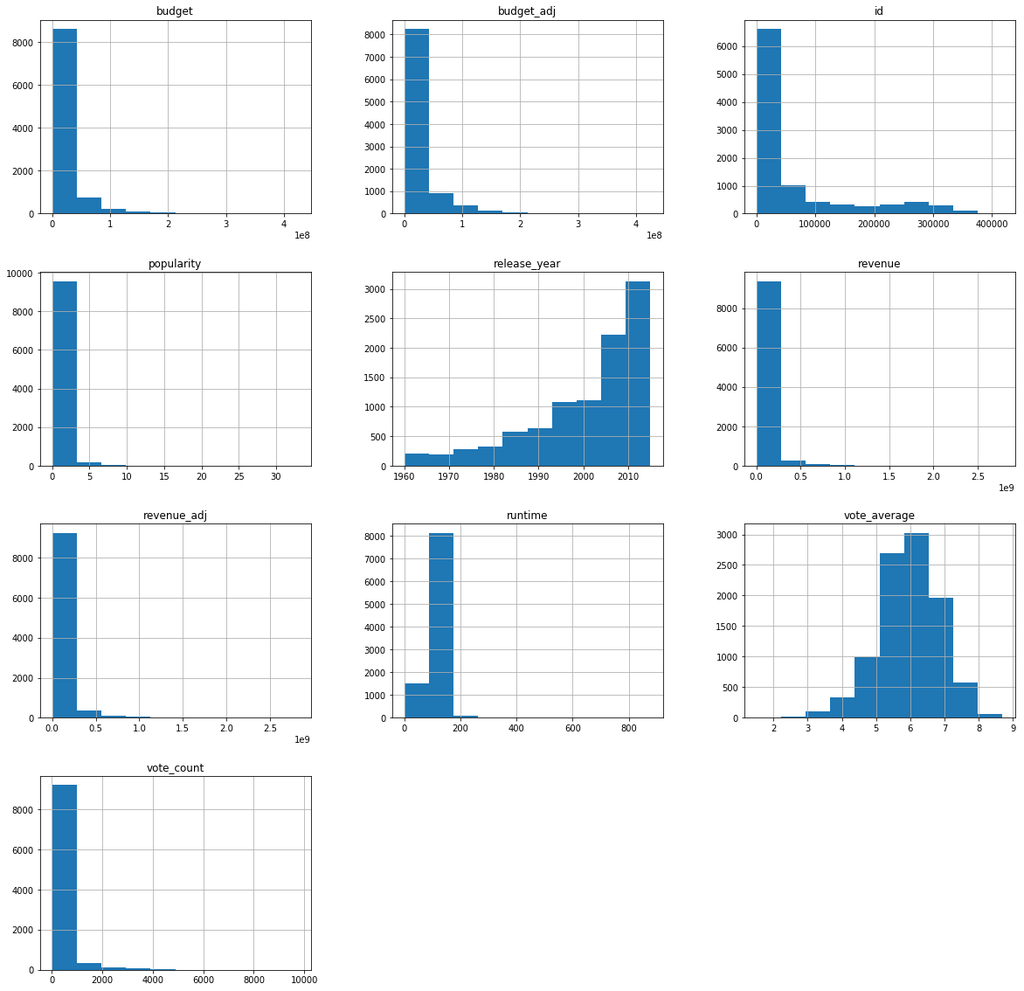

```python
df.hist(figsize=(20,20))
```

### Which year has the highest release of movies?

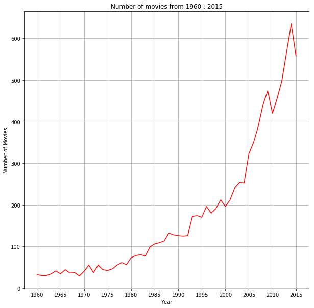

```python
#count no of movies for each year
df_year = df.groupby('release_year').count()['id']

#plotting the graph
df_year.plot(xticks=np.arange(1960,2020,5),figsize=(10,10), color='red')
plt.title('Number of movies from 1960 : 2015')
plt.xlabel('Year')
plt.ylabel('Number of Movies')
#adjust the background of the graph to grid to be more readable
plt.grid(True);
```

```
            As showen year 2014 has the highest release of movies
```

### What is the most common average vote?

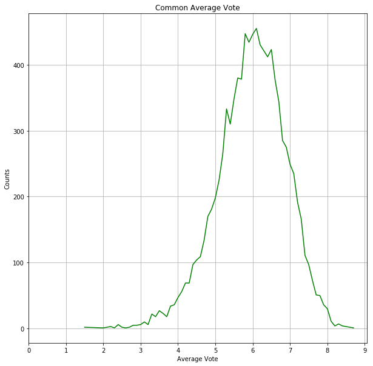

```python
# count number of each vote rate
votes = df.groupby('vote_average').count()['id']
#plot the graph
votes.plot(xticks=np.arange(0,10,1),figsize=(10,10),color='green')
plt.title('Common Average Vote')
plt.xlabel('Average Vote')
plt.ylabel('Counts')
plt.grid(True);
```

```
            As shown the most repeated average vote is "6.1"
```

### Is there any correlation between Budget and Revenue?

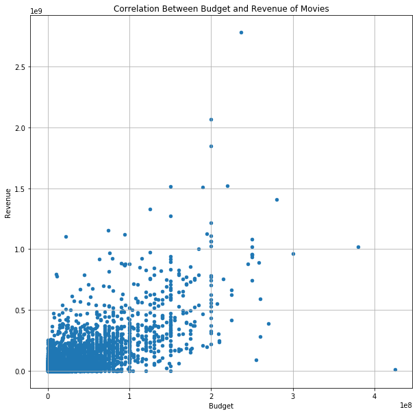

```python
graph1 = df.plot(x='budget',y='revenue',kind='scatter',figsize=(10,10))
plt.title("Correlation Between Budget and Revenue of Movies")
plt.xlabel('Budget')
plt.ylabel('Revenue')
plt.grid(True);
```

```
       There is a positive correlation Between Budget and Revenue of Movies
```

### Is there any correlation between Popularity and Revenue?

```python
graph2 = df.plot(x='popularity',y='revenue',kind='scatter',figsize=(10,10))
plt.title('Correlation Between Popularity and Revenue of Movies')
plt.xlabel('Popularity')
plt.ylabel('Revenue')
plt.grid(True);
```

[output not shown]

[output not shown]

### Is there any correlation between Vote Average and Revenue?

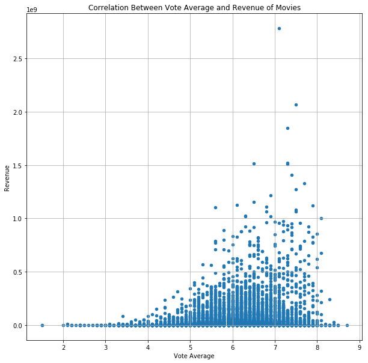

```python
graph3 = df.plot(x='vote_average',y='revenue',kind='scatter',figsize=(10,10))
plt.title("Correlation Between Vote Average and Revenue of Movies")
plt.xlabel('Vote Average')
plt.ylabel('Revenue')
plt.grid(True);
```

### Is there any correlation between Vote Average and Popularity?

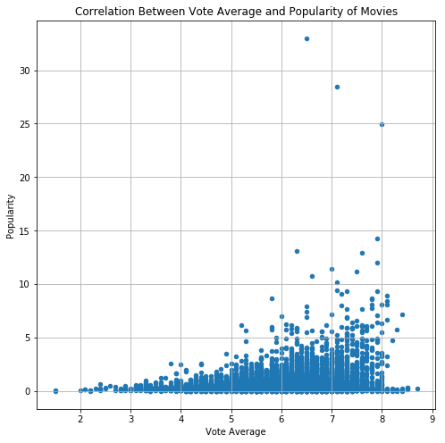

```python
graph4 = df.plot(x='vote_average',y='popularity',kind='scatter',figsize=(8,8))
plt.title("Correlation Between Vote Average and Popularity of Movies")
plt.xlabel('Vote Average')
plt.ylabel('Popularity')
plt.grid(True);
```

### Who is the top 10 Directors?

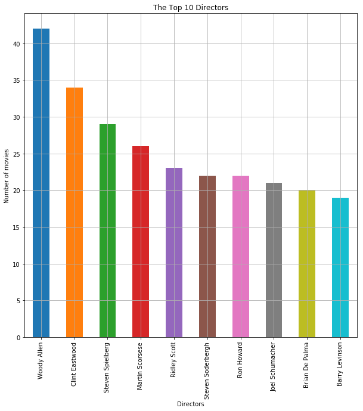

```python
#count no of movies for esch director
directors = df.groupby('director').count()['id'].sort_values(ascending = False)
#choose the top 10 of them
top_directors = directors[:10].plot(kind='bar',figsize=(10,10),width=0.5)
plt.title('The Top 10 Directors')
plt.xlabel('Directors')
plt.ylabel('Number of movies')
plt.grid(True);
```

### Which Genre Has The Highest Release Of Movies?

```python
#create function to split genres & cast and return the counts of each genres and actor

def split_data(x):
    #concatenate the content of all rows with seperator |
    concat_data = df[x].str.cat(sep='|')
    #split the above data and store it in pandas series
    splitted_data =pd.Series(concat_data.split('|'))
    #counts values for each genres or actor
    counts = splitted_data.value_counts()

    return counts
```

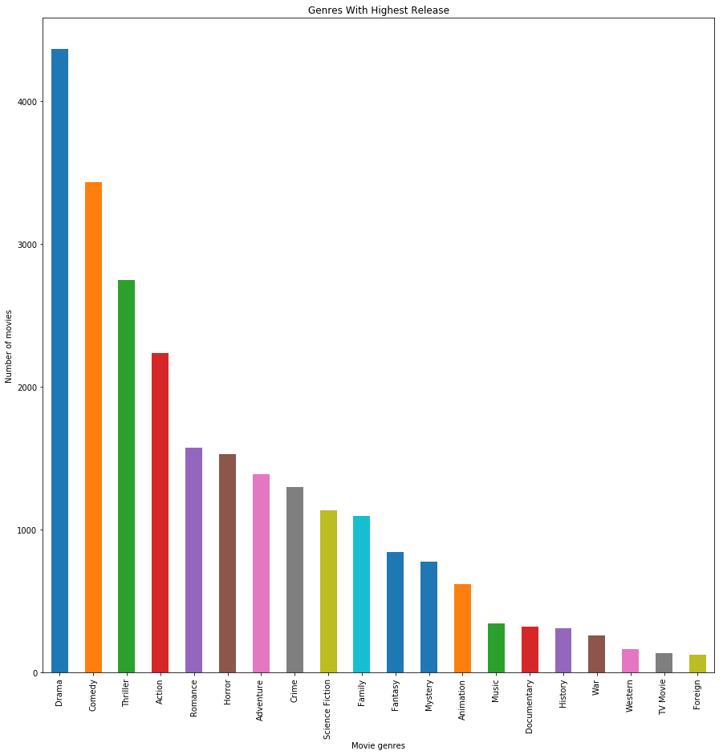

```python
split_data('genres').plot(kind='bar',figsize=(15,15),width=0.5)
plt.title('Genres With Highest Release')
plt.xlabel('Movie genres')
plt.ylabel('Number of movies');
```

### Who is the actor that has The Highest Release Of Movies?

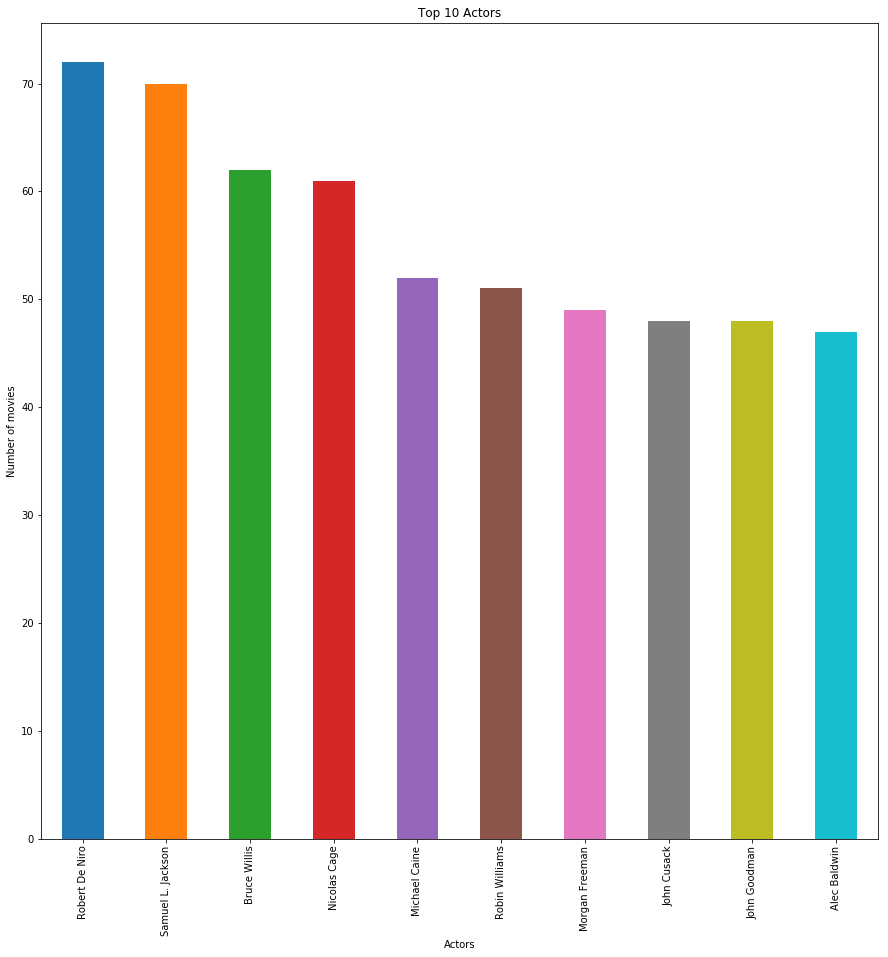

```python
#use split_data function with cast column and extract the first 10 actors
top_10 = split_data('cast')[0:10].plot(kind='bar',figsize=(15,15),width=0.5)
plt.title('Top 10 Actors')
plt.xlabel('Actors')
plt.ylabel('Number of movies');
```

## Conclusions

### Data Limitation:

- The dataset has alot of missing values and I tried to overcome this limitation by deleting some columns like: ('imdb_id','homepage','tagline','keywords','overview') and then I dropped all NAN values.
- I have to split the data of columns ('genres', 'cast') seperated by '|' into lists to be able to use them in my analysis and this takes more time from me.

```python
from subprocess import call
call(['python', '-m', 'nbconvert', 'Investigate_a_Dataset.ipynb'])
```

```
0
```